# Data Visualization Assignment

Author

Victoria Baran

# Story Summary

When examining the Rolling Stone Top 500, something that instantly stood out was how certain albums and genres gained appreciation from critics between 2003 and 2020, while others lost it. Blues/Blues Rock went from 61 to 29, while Soul/Gospel/R&B went up by 20 albums, and Hip-Hop more than doubled within 17 years. This led to a central question: did these genres rise because of newly released albums, or were their albums previously overlooked? In other words, are the albums added in 2020 mainly made up of new releases, or were they released in time to be on the 2003 list and simply not acknowledged until almost two decades later?

To answer this, I compared the number of albums per genre on each list, then looked at when the added albums were released and their allocated genre. Interestingly, the analysis showed that soul and hip-hop grew the most while much of what was added already existed in 2003, specifically out of 174 albums, 113 of them were released in time for the 2003 Rolling Stones list. This suggests that the 2020 list was less an update on new music but rather a second chance for older music.

# Version A: Scientific Article

Albums were classified by genre and by list membership held. An album is classified as ‘added’ the album appears on the 2020 list, but not on the 2003 list. If an added album was released in or before 2003, it is described as an ‘older addition’.

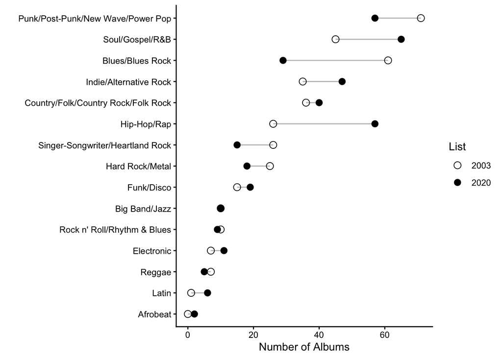

Figure 1. The number of albums in each genre on the 2003 and 2020 Rolling Stone Top 500 lists (n = 500 per list). Open circles indicate the number present in 2003, and filled circles indicate the number in 2020. Albums with no genre label are excluded (125 in 2003; 110 in 2020)

Examining how genres are represented between editions, the data show that Blues/Blues Rock declined from 61 to 29 albums, while Soul/Gospel/R&B increased from 45 to 65 and Hip-Hop more than doubled from 26 to 57

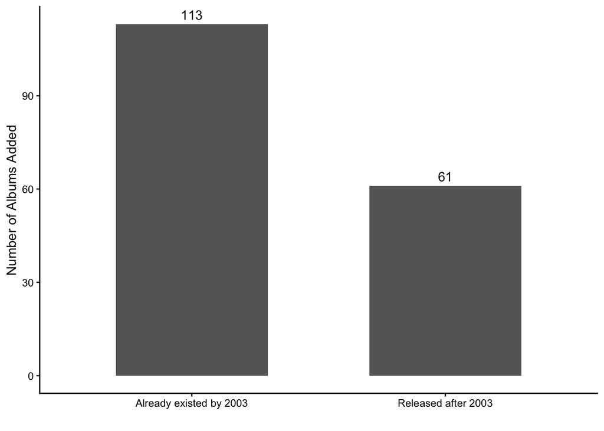

Figure 2. Albums added to the 2020 Rolling Stone Top 500 list that were not on the 2003 list (n=174). The left bar shows albums that already existed in 2003 (n = 113), and the right bar shows albums released after 2003 (n = 61).

Out of 174 albums that appeared on the 2020 list but not on the 2003 list, 113 (65%) had been released in or prior to 2003, indicating most added albums were not new releases

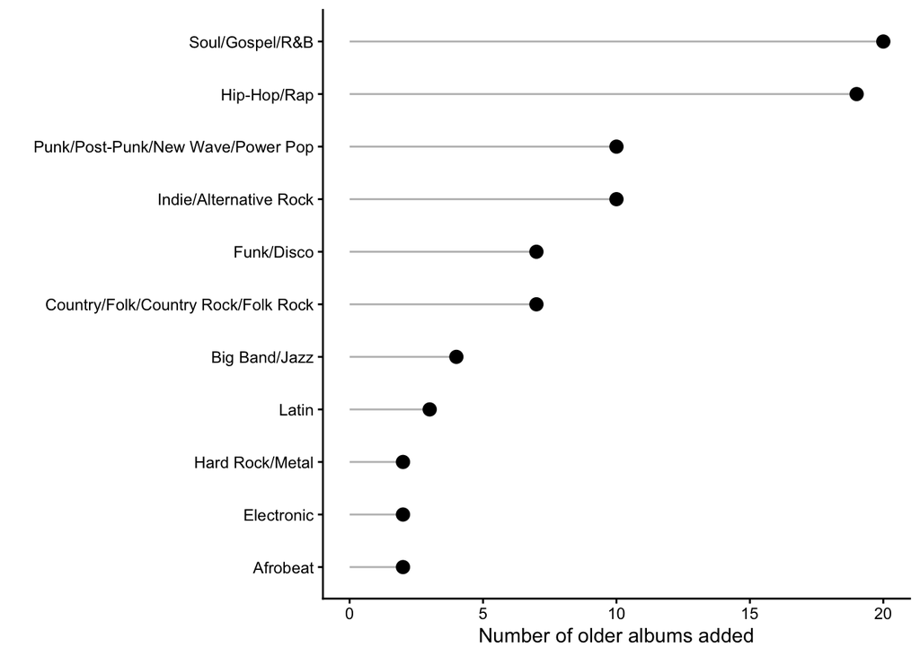

Figure 3. Genres of albums added to the Rolling Stone Top 500 in 2020 that were released in or before 2003 (n = 113). Genres are ordered from the most albums added (Soul/Gospel/R&B, n = 20) to the fewest (n = 2). The 27 albums with no genre label were excluded.

Among older additions, Soul/Gospel/R&B (n = 20) and Hip-Hop/Rap (n = 19) were the most prevalent additions to the 2020 list

# Version B: Accessible Version

## What Goes Up, Must Come Down

Between 2003 and 2020, some genres gained and lost spots in the Rolling Stone Top 500 while others lost them. Blues lost more than half its spots on the list, while hip-hop more than doubled. This chart shows the genres that gained or lost at least 10 albums; hover over this chart, and any ones below, to see the exact numbers

[interactive chart not shown]

## Most Of The ‘New’ Albums Weren’t New

An easy assumption is that the list changed because new music came out. However, about two out of every three albums added in 2020 were already around when the 2003 list was made.

[interactive chart not shown]

## Soul and Hip-Hop Make A Comeback

Which older albums finally made it? Mostly soul and hip-hop, as seen in the dark blue bars. These albums were not new; rather just noticed late.

[interactive chart not shown]

# Data and Source Note

The data came from a data-set from TidyTuesday (https://github.com/rfordatascience/tidytuesday/blob/main/data/2024/2024-05-07/readme.md) named ‘Rolling Stone Album Rankings’. The data set lists 691 albums and their rankings on the 2003, 2012, and 2020 Rolling Stone 500 list. Charts come from R Graph Gallery (https://r-graph-gallery.com/) Transformations included renaming a genre label from ‘Blues/Blues ROck’ to ‘Blues/Blues Rock’ to correct typos. Additionally, 164 albums had no label (125 on 2003 list, 110 on the 2020 list); those were excluded from the figures which limits the genre comparison.